[figure not shown]

7

TH

ATMOSPHERIC SCIENCES SYMPOSIUM

28-30 APRIL 2015

ISTANBUL

PROCEEDINGS

EDITORS

DOÇ.DR. ALİ DENİZ

BAHTİYAR EFE

BİHTER DURNA

PELİN CANSU ÇAVUŞ

i

Chairs

Assoc. Prof. Dr. Ali DENİZ, İstanbul Technical University (Chair)

Prof. Dr. Mustafa ÇIKRIKÇI, İstanbul Aydın University (Co-chair)

Assoc. Prof. Dr. Hüseyin TOROS, İstanbul Technical University (Vice Chair)

Prof. Dr. Osman UÇAN, İstanbul Aydın University (Vice Chair)

Honoree Chairs

Prof.Dr Mehmet KARACA, Rector, İstanbul Technical University

Dr. Mustafa AYDIN, Head of Trustees, İstanbul Aydın University

Prof. Dr. Zekai ŞEN, Head of Water Foundation

Prof. Dr. Yadigar İZMİRLİ, Rector, İstanbul Aydın University

Prof. Dr. Lütfi AKÇA, Counselor in Ministry of Forestry and Water Affairs

Prof. Dr. Mustafa ÖZTÜRK, Counselor in Min. of Environment and Urban Planning

Bilal EKŞİ, General Manager, Directorate General of Civil Aviation

Hamdi TOPÇU, Chairman of the Board, Turkish Airlines

Assos. Prof. Dr. Temel KOTİL, General Manager, Turkish Airlines

İsmail GÜNEŞ, General Manager, Meteorological Service

Akif ÖZKALDI, General Manager, State Hydraulic Works

Funda OCAK, Deputy Genaral Manager, State Airports Authority

Fırat ÇUKURÇAYIR, Head of the Chamber of Meteorological Engineers

Ramazan ÖZÇELİK, Regional Director, Marmara Clean Air Centre

Advisory Board

Prof. Dr. Ahmet Duran ŞAHİN, İstanbul Technical University, Turkey

Prof. Dr. Celal Nazım İREM, İstanbul Aydın University, Turkey

Prof. Dr. Hasan SAYGIN, İstanbul Aydın University, Turkey

Prof. Dr. H. Sema TOPÇU, İstanbul Technical University, Turkey

Prof. Dr. İbrahim ÖZKOL, İstanbul Technical University, Turkey

Prof. Dr. Kasım KOÇAK, İstanbul Technical University, Turkey

Prof. Dr. Levent ŞAYLAN, İstanbul Technical University, Turkey

Prof. Dr. M. Orhan KAYA, İstanbul Technical University, Turkey

Prof. Dr. Selahattin İNCECİK, İstanbul Technical University, Turkey

Prof. Dr. Zafer ASLAN, İstanbul Aydın University, Turkey

Prof. Dr. Zahit MECİTOĞLU, İstanbul Technical University, Turkey

Prof. Dr. Zerefşan KAYMAZ, İstanbul Technical University, Turkey

VII. Atmospheric Science Symposium, 28,30 April 2015 İstanbul, www.atmosfer.itu.edu.tr

29

Isınma ve Soğuma Derece Günlerin Elektrik Tüketimi Üzerindeki Etkisi

Derya AYDIN (1), Ahmet Faruk KAVAK (2), Hüseyin TOROS (3)

1İstanbul Teknik Üniversitesi, Uçak ve Uzay Bilimleri Fakültesi, Meteoroloji Mühendisliği, İstanbul,

(aydiinderya@gmail.com)

2Boğaziçi Üniversitesi, İdari ve İktisadi Bilimler Fakültesi, İktisat (ahmet_kavak91@yahoo.com)

3İstanbul Teknik Üniversitesi, Uçak ve Uzay Bilimleri Fakültesi, Meteoroloji Mühendisliği, İstanbul,

(toros@itu.edu.tr)

ÖZET

Dünyadaki trende paralel olarak liberalleşen Türkiye Enerji Piyasası’nda elektrik talep tahmini konusu önemli

bir çalışma alanı haline gelmektedir. İstatistiki araçlar kullanılarak yapılan öngörülerde hali hazırda yüksek

volatilite gösteren elektrik talebini genellikle üretim göstergesi (GSYİH) takvim etkisi ve hava sıcaklığı ile

açıklayan yöntemler mevcuttur. Bu etkenlerden elektrik talebine en çok etki edeceğini düşündüğümüz hava

sıcaklığını, ısıtma derece gün ve soğutma derece gün olarak kullanmayı uygun bulduk. Isıtma derece gün, bir

günlük periyodun ne kadar soğuk geçtiğini ve ne kadar ısınmaya ihtiyaç duyulduğunu, soğutma derece gün de

bir günlük periyodun ne kadar sıcak geçtiğini ve ne kadar soğutmaya ihtiyaç duyulduğunu gösteren birimdir.

Dış ortamın sıcaklığı hesaba katılarak baz alınan sıcaklığa göre soğuğun yada sıcağın şiddeti belirlenir.

Çalışmamızda, ısınma ve soğuma için harcanan enerjiyi yansıtan ısınma derece günler ve soğuma derece günleri,

gün tipi (takvimsel etki) etkisinden arındırılmış tüketim ile bir korelasyon analizine tabi tutarak; meteorolojik

etmenlerin elektrik piyasası üzerindeki etkisini daha objektif bir yöntemle göstermeyi amaçladık.

Anahtar kelimeler: Isıtma derece gün, soğutma derece gün, elektrik tüketim

ABSTRACT

Energy demand forecasts are becoming an important topic in liberalized or semi-liberalized energy markets

around the world, such as Turkish Energy Market. In explaining electricity demand, forecast models mainly

focus on development indexes like GDP (for long-term forecasts), historical distribution of electricity demand

and temperature (for short-term forecasts) to diagnose the dynamics of such a volatile-natured variable. In our

work, we will try to explain this volatility via HDD (Heating Degree Day) and CDD (Cooling Degree Day)

values. Respectively these indexes indicate how much change in temperature is needed for heating or cooling for

a given day. This way it will be easier to reflect the energy spent for heating or cooling in a forecast model.

Another novel feature of our work will be exclusion of the calendar effect on time series representing electricity

demand. After this phase, we will enable ourselves to analyze the correlation between electricity demand and

temperature more objectively and more accurately. Finally we will argue that a forecast model built on these

assumptions will be more successful in explaining future consumption levels of electricity in a given network.

Key words: Heating degree day, cooling degree day, electricity demand

1. Giriş

Şehirlerdeki arazi kullanımının değişmesi, beton yapıların artması, yüksek binalar, kalabalık nüfus ve yoğun

hava kirliliği hava sıcaklıklarının çevresindeki kırsal kesimlere oranla daha yüksek seviyelere ulaşmasına neden

olmaktadır. Bu durum kentsel ısı adası olarak, ilk kez 1820’de Luke Howard tarafından tanımlanmış ve literatüre

girmiştir. (Yüksel, Ü., D., Yılmaz, O., 2008) Şehirlerdeki kara kullanımının değişimi ısının radyatif transferini ve

depolanmasını etkileyerek, hissedilir ve gizli ısıdaki dengeyi değiştirmektedir. Bu nedenle yüksek binaların

yoğun olduğu bölgelerdeki hava sıcaklığı kırsal çevresine göre daha yüksek olmaktadır (Vardoulakis, E., ve ark.,

2013) Kentsel ısı adası sıcaklıkları yükseltmesinin yanı sıra enerji talebinin artmasında da etkilidir.

Türkiye’de elektrik enerjisi talebi, artan nüfus, şehirleşme, sanayileşme, teknolojinin yaygınlaşması ve refah

artışına paralel olarak yükselmesini sürdürmektedir. Türkiye’de elektrik enerjisi tüketimi, geçen 40 yılda, yıllık

VII. Atmospheric Science Symposium, 28,30 April 2015 İstanbul, www.atmosfer.itu.edu.tr

30

ortalama %10’luk bir hızla büyümüştür. Bu artış hızı son 20 yılda % 8,5 düzeyine gerilemiştir. Azalan artış

hızına rağmen talebin tüketimde doyuma ulaşılıncaya kadar daha uzun bir süre yüksek oranlarda artmaya devam

etmesi beklenmektedir. (Güneği, O. O., 2002, Demirel, Ö., ve ark, 2010)

Enerjinin tüketicilere ucuz ve kaliteli olarak sunulması, elektrik enerjisinin üretimini, iletimini ve dağıtımını

yapan kuruluşların hedefidir. Bu amacı güvenilir ve ekonomik bir şekilde yerine getirmek için elektrik enerji

sistemleri, enerji ihtiyacını ve trafodan çekilen anlık yükü (puant) karşılayabilecek şekilde geliştirilmelidir.

Enerji üretim, iletim ve dağıtım sistemlerinin düzenli olarak planlanması, talep değişimlerinin takibi, arz

oluşturulması ve enerji eksikliğinin yaşanmamamı açısından önem arz etmektedir. Bu planlamalar yapılırken de

en önemli safhayı enerji talep tahminleri oluşturmaktadır. (Demirel, Ö.,ve ark., 2010)

Hava sıcaklığının şiddetini temsil etmesi açısından ısıtma ve soğutma derece günler çalışmalarda sıklıkla

kullanılmaktadır. Isıtma ve soğutma derece gün, belirli bir zamanda belirli bir baz değerine göre hava

sıcaklığının şiddetini ifade etmekte kullanılır. Isıtma derece gün sayısı (heating degree day, HDD) bir gün içinde

ortalama hava sıcaklığının, baz değerine oranla ne kadar soğuk olduğunu ifade eder. Soğutma derece gün sayısı (

cooling degree day, CDD) ise bir günün ortalama sıcaklığının, baz değerine oranla ne kadar sıcak olduğunu ifade

eder. Başka bir değişle ısıtma derece gün sayısının yüksek olması o bölgede ısınma ihtiyacının yüksek olduğunu

anlamına gelmektedir. Soğutma derece gün sayısı ise aynı şekilde soğutmaya ihtiyaç duyulan gün sayısını ifade

etmektedir.

Çalışmada İstanbul un seçilmesinin nedeni hızlı şehirleşme ve sanayileşme ile kent ısı adasının etkili biçimde

görülmesi ve yoğun popülasyonu nedeniyle ülkedeki enerji tüketiminin en çok olduğu şehir olmasıdır. Çalışma

sonucunda sıcaklık ile elektrik tüketimi arasındaki ilişkinin yüksek olduğunun gösterilmesi ve bu doğrultuda

elektrik talebinin yüksek doğrulukla tahmin edilmesi için model geliştirmek amaçlanmıştır.

2. Metot ve Materyal

Çalışmada İstanbul iline ait Aralık 2010 – Aralık 2014 yılları arası günlük sıcaklık verileri ve günlük elektrik

tüketim verileri kullanılmıştır. Sıcaklık verileri wunderground.com sitesinden, tüketim verileri de Boğaziçi

Elektrik A.Ş.’den temin edilmiştir. Sıcaklık verileri kullanılarak ısıtma ve soğutma derece gün sayıları ( HDD ve

CDD) hesaplanmıştır. Isıtma derece gün ve soğutma derece gün sayıları farklı yöntemler kullanılarak

belirlenebilir. Bu çalışmada Avrupa Birliği İstatistik Ofisi (Eurostat) tarafından belirlenen yöntem kullanılmıştır.

Türkiye oldukça büyük yüzey alanına sahiptir ve birçok farklı iklimi barındırır. Her bölgede konfor sıcaklığının

aynı olması beklenemez. Ülkenin doğusunda ısıtma ihtiyacı için beklenen sıcaklıklar daha düşük, fakat daha

ılıman iklime sahip batı bölgeler için bu eşik sıcaklığı daha yüksektir. Bu nedenle çalışmanın yapılacağı İstanbul

için farklı baz değerleri seçilerek ısıtma ve soğutma derece gün sayıları belirlenmiş ve elektrik tüketim ile olan

korelasyonları hesaplanmıştır. Böylece elektrik tüketimi ile en büyük korelasyona sahip olan sıcaklık değerleri

daha objektif bir şekilde saptanmıştır.

Çalışmamızın ikinci bölümünde ise hava sıcaklığı-tüketim ilişkisini temel alan basit bir tahmin modeli

oluşturarak hava durumu tahminlerini girdi olarak kullanabilecek doğrusal bir regresyon ile enerji tüketimine

yönelik isabetli öngörüler sunabilecek bir denklem kurmak amaçlanmıştır.

VII. Atmospheric Science Symposium, 28,30 April 2015 İstanbul, www.atmosfer.itu.edu.tr

31

2.1. Doğrusal Regresyon Modeli

İki ya da daha fazla değişkenin ortak dinamiklerini belirleyip aralarındaki ilişkiyi sayısal olarak ifade edebilmek

üzerine özellikle iktisat alanında birçok araç sunan ekonometri disiplininde doğrusal regresyon çok temel bir

yere sahiptir. Doğrusal regresyon modellerinin tanımda örnek verilen dışında zaman serilerini kullanarak

geleceğe yönelik tahminler yapabilme gibi çok önemli işlevleri vardır. Burada bahsedilen zaman serileri belirli

bir değişkenin herhangi bir zaman aralığı için düzenli aralıklarla verilen gözlemleridir. Doğrusal regresyon

modeli, girdi olarak kullandığı bir değişkenin(açıklayıcı değişken) gelecek projeksiyonunu kullanarak,

gerçekleşen değerler üzerinden sayısal ilişkilerini açıkladığı matematiksel model üzerinden başka bir

değişkene(açıklanan değişken) yönelik öngörüler sunabilmektedir. Aşağıda basit bir doğrusal regresyon

Basit bir örneklendirme yapılırsa,

sayısı olacaktır. Doğrusal regresyon modelinde amaç basit olarak en doğru  değerlerini bularak, denklemin son

gerçekleşen değer – denklemin verdiği değer) minimum seviyede olmasıdır. (

burada sabit bir sayıya karşılık gelmektedir, öyle ki tüm açıklayıcı değişkenler “0” olduğunda açıklanan

değişkenin değerinin ne kadar olacağına dair bir başlangıç noktası verir, örnek üzerinden gidersek işsizlik ve

polis sayısının “0” olduğu durumda kaç adli vaka görülür). Doğrusal denklemde bu metotla β değerlerinin

belirlenmesi literatürde “Optimal Least Squares” olarak(OLS) isimlendirilmiştir.

Çalışmamız içerisinde iki bölümde regresyon modeli kullanılacaktır:

1. Tüketim değerlerini takvimsel etkiden arındırma

2. HDD ve CDD’yi açıklayıcı değişken olarak kullanan doğrusal bir tahmin modeli oluşturulması

2.2. Isıtma Derece Gün ve Soğutma Derece Gün Sayıları Hesaplanması

Tb= Baz sıcaklık değeri

Tm= Günlük ortalama sıcaklık

d= Gün sayısı

HDD= 0 Eğer Tm >Tb

Tb= Baz sıcaklık değeri

Tm= Günlük ortalama sıcaklık

d= Gün sayısı

CDD= 0 Eğer Tm<Tb

[figure not shown]

VII. Atmospheric Science Symposium, 28,30 April 2015 İstanbul, www.atmosfer.itu.edu.tr

32

date

HDD14

HDD16

HDD18

date2

CDD20

CDD22

CDD24

1.12.2010

0

0

0

1.6.2011

0

0

0

2.12.2010

0

0

0

2.6.2011

0

0

0

3.12.2010

0

0

0

3.6.2011

1,01375

0

0

4.12.2010

0

0

0

4.6.2011

2,284583

0,284583

0

5.12.2010

4,01375

6,01375

8,01375

5.6.2011

2,534583

0,534583

0

6.12.2010

5,07625

7,07625

9,07625

6.6.2011

2,985833

0,985833

0

7.12.2010

3,319167

5,319167

7,319167

7.6.2011

2,735833

0,735833

0

8.12.2010

0,63875

2,63875

4,63875

8.6.2011

2,45125

0,45125

0

9.12.2010

0

0,631667

2,631667

9.6.2011

5,14625

3,14625

1,14625

10.12.2010

6,479167

8,479167

10,47917

10.6.2011

3,4375

1,4375

0

11.12.2010

10,13875

12,13875

14,13875

11.6.2011

0

0

0

12.12.2010

11,40958

13,40958

15,40958

12.6.2011

0,958333

0

0

13.12.2010

9,257083

11,25708

13,25708

13.6.2011

1,305417

0

0

14.12.2010

8,458333

10,45833

12,45833

14.6.2011

0,895833

0

0

15.12.2010

9,04875

11,04875

13,04875

15.6.2011

2,132083

0,132083

0

16.12.2010

6,243333

8,243333

10,24333

16.6.2011

1,993333

0

0

17.12.2010

9,007083

11,00708

13,00708

17.6.2011

2,305833

0,305833

0

18.12.2010

4,631667

6,631667

8,631667

18.6.2011

3,291667

1,291667

0

19.12.2010

4,895833

6,895833

8,895833

19.6.2011

3,360833

1,360833

0

20.12.2010

3,007083

5,007083

7,007083

20.6.2011

3,465417

1,465417

0

21.12.2010

0

1,5625

3,5625

21.6.2011

3,847083

1,847083

0

22.12.2010

0,590417

2,590417

4,590417

22.6.2011

4,07625

2,07625

0,07625

23.12.2010

1,347083

3,347083

5,347083

23.6.2011

4,60375

2,60375

0,60375

24.12.2010

0,67375

2,67375

4,67375

24.6.2011

4,569167

2,569167

0,569167

25.12.2010

0

0,73625

2,73625

25.6.2011

3,798333

1,798333

0

26.12.2010

0

1,493333

3,493333

26.6.2011

0,243333

0

0

27.12.2010

1,875

3,875

5,875

27.6.2011

0

0

0

28.12.2010

7,82625

9,82625

11,82625

28.6.2011

1,117917

0

0

29.12.2010

8,784583

10,78458

12,78458

29.6.2011

0,625

0

0

30.12.2010

8,479583

10,47958

12,47958

30.6.2011

2,514167

0,514167

0

31.12.2010

9,5

11,5

13,5

1.7.2011

3,54875

1,54875

0

1.1.2011

9,944583

11,94458

13,94458

2.7.2011

2,32625

0,32625

0

2.1.2011

5,51375

7,51375

9,51375

3.7.2011

4,631667

2,631667

0,631667

3.1.2011

6,180833

8,180833

10,18083

4.7.2011

2,35375

0,35375

0

4.1.2011

8,889167

10,88917

12,88917

5.7.2011

3,520833

1,520833

0

5.1.2011

7,79875

9,79875

11,79875

6.7.2011

5,076667

3,076667

1,076667

6.1.2011

10,45125

12,45125

14,45125

7.7.2011

5,145833

3,145833

1,145833

7.1.2011

8,472083

10,47208

12,47208

8.7.2011

6,3125

4,3125

2,3125

8.1.2011

8,617917

10,61792

12,61792

9.7.2011

5,722083

3,722083

1,722083

9.1.2011

7,402917

9,402917

11,40292

10.7.2011

5,979167

3,979167

1,979167

10.1.2011

6,472083

8,472083

10,47208

11.7.2011

6,354167

4,354167

2,354167

11.1.2011

5,367917

7,367917

9,367917

12.7.2011

6,635417

4,635417

2,635417

12.1.2011

4,312083

6,312083

8,312083

13.7.2011

6,125

4,125

2,125

13.1.2011

5,375417

7,375417

9,375417

14.7.2011

6,347083

4,347083

2,347083

14.1.2011

5,492917

7,492917

9,492917

15.7.2011

7,451667

5,451667

3,451667

15.1.2011

5,632083

7,632083

9,632083

16.7.2011

6,305833

4,305833

2,305833

16.1.2011

4,8475

6,8475

8,8475

17.7.2011

8,382083

6,382083

4,382083

17.1.2011

6,9925

8,9925

10,9925

18.7.2011

7,944583

5,944583

3,944583

18.1.2011

7,569583

9,569583

11,56958

19.7.2011

7,257083

5,257083

3,257083

19.1.2011

7,507083

9,507083

11,50708

20.7.2011

7,514167

5,514167

3,514167

20.1.2011

6,9375

8,9375

10,9375

21.7.2011

7,784583

5,784583

3,784583

21.1.2011

4,347083

6,347083

8,347083

22.7.2011

7,687917

5,687917

3,687917

22.1.2011

2,444167

4,444167

6,444167

23.7.2011

8,0975

6,0975

4,0975

23.1.2011

3,784583

5,784583

7,784583

24.7.2011

7,54875

5,54875

3,54875

24.1.2011

8,222083

10,22208

12,22208

25.7.2011

7,014167

5,014167

3,014167

25.1.2011

9,430417

11,43042

13,43042

26.7.2011

7,944583

5,944583

3,944583

[figure not shown]

VII. Atmospheric Science Symposium, 28,30 April 2015 İstanbul, www.atmosfer.itu.edu.tr

33

26.1.2011

9,472083

11,47208

13,47208

27.7.2011

8,458333

6,458333

4,458333

27.1.2011

9,48625

11,48625

13,48625

28.7.2011

8,270958

6,270958

4,270958

28.1.2011

7,42375

9,42375

11,42375

29.7.2011

7,6525

5,6525

3,6525

29.1.2011

8,527917

10,52792

12,52792

30.7.2011

7,708333

5,708333

3,708333

30.1.2011

11,00667

13,00667

15,00667

31.7.2011

7,277917

5,277917

3,277917

31.1.2011

12,20125

14,20125

16,20125

1.8.2011

7,159583

5,159583

3,159583

1.2.2011

11,91

13,91

15,91

2.8.2011

6,652917

4,652917

2,652917

2.2.2011

11,42375

13,42375

15,42375

3.8.2011

6,180417

4,180417

2,180417

3.2.2011

9,117917

11,11792

13,11792

4.8.2011

6,354167

4,354167

2,354167

4.2.2011

8,055417

10,05542

12,05542

5.8.2011

5,958333

3,958333

1,958333

5.2.2011

7,98625

9,98625

11,98625

6.8.2011

5,090417

3,090417

1,090417

6.2.2011

5,645833

7,645833

9,645833

7.8.2011

5,11125

3,11125

1,11125

7.2.2011

5,409583

7,409583

9,409583

8.8.2011

5,332917

3,332917

1,332917

8.2.2011

6,527917

8,527917

10,52792

9.8.2011

5,583333

3,583333

1,583333

9.2.2011

5,32625

7,32625

9,32625

10.8.2011

5,527917

3,527917

1,527917

10.2.2011

7,91

9,91

11,91

11.8.2011

0,92375

0

0

11.2.2011

8,5

10,5

12,5

12.8.2011

0,777917

0

0

12.2.2011

4,145833

6,145833

8,145833

13.8.2011

3,340417

1,340417

0

13.2.2011

7,090417

9,090417

11,09042

14.8.2011

4,402917

2,402917

0,402917

14.2.2011

7,23625

9,23625

11,23625

15.8.2011

5,430417

3,430417

1,430417

15.2.2011

8,98625

10,98625

12,98625

16.8.2011

6,617917

4,617917

2,617917

16.2.2011

9,757083

11,75708

13,75708

17.8.2011

7,284583

5,284583

3,284583

17.2.2011

7,360833

9,360833

11,36083

18.8.2011

5,8125

3,8125

1,8125

18.2.2011

1,555417

3,555417

5,555417

19.8.2011

4,632083

2,632083

0,632083

19.2.2011

3,055417

5,055417

7,055417

20.8.2011

3,92375

1,92375

0

20.2.2011

8,131667

10,13167

12,13167

21.8.2011

4,395833

2,395833

0,395833

21.2.2011

8,208333

10,20833

12,20833

22.8.2011

4,895833

2,895833

0,895833

22.2.2011

7,027917

9,027917

11,02792

23.8.2011

4,340417

2,340417

0,340417

23.2.2011

5,916667

7,916667

9,916667

24.8.2011

4,88875

2,88875

0,88875

24.2.2011

6,805417

8,805417

10,80542

25.8.2011

5,242917

3,242917

1,242917

25.2.2011

7,8475

9,8475

11,8475

26.8.2011

4,8475

2,8475

0,8475

26.2.2011

11,57625

13,57625

15,57625

27.8.2011

4,742917

2,742917

0,742917

27.2.2011

11,29208

13,29208

15,29208

28.8.2011

4,027917

2,027917

0,027917

28.2.2011

9,152917

11,15292

13,15292

29.8.2011

4,4725

2,4725

0,4725

30.8.2011

2,708333

0,708333

0

31.8.2011

3,618333

1,618333

0

Table 1: 2011 yılı İstanbul'un günlük ısıtma ve soğutma derece gün sayıları

Tablo 1’de 2011 yılı için hesaplanan günlük HDD ve CDD sayıları mevcuttur. HDD değerleri için Aralık- Ocak-

Şubat aylarını kapsayan kış dönemi verileri; CDD değerleri için de Haziran- Temmuz- Ağustos aylarının

kullanılmıştır. Fakat Tablo 1 temsili olması açısından sadece 2011 yılı değerlerini göstermektedir.

2.3. Günlük Tüketimin Takvim Etkisinden Arındırılması

Daha önce bahsedildiği gibi bu aşamada doğrusal regresyon denklemi kurularak değişik günlerin tüketim

karakteristikleri incelenmiştir. Enerji piyasasında şehir şebekelerinin enerji tedariği ile yükümlü dağıtım

şirketlerinin talep tahmini için kullandıkları “EPDK Calendar” bu konuda çalışmamıza önemli bir katkı

sunacaktır. Şöyle ki Enerji Piyasası Denetleme Kurulunun yayınladığı bu gün tipi standardına göre haftanın 7

günü, bayram arifeleri, resmi tatiller ve bayram günleri toplamda 10 adet olmak üzere farklı gün tipi kodları

almaktadır. Aşağıdaki listede gün tipleri detaylandırılmıştır.

[figure not shown]

VII. Atmospheric Science Symposium, 28,30 April 2015 İstanbul, www.atmosfer.itu.edu.tr

34

Table 2: EPDK gün tipi kodları

1

Pazar

2

Pazartesi

3

Salı

4

Çarşamba

5

Perşembe

6

Cuma

7

Cumartesi

8

Dini Günler

9

Resmi Tatiller

10

Arife günleri

Burada kullanılacak regresyon modeli 10 adet basit değişken (“1” ya da “0” değerlerini alan “dummy variable”)

ve tüketim serisi içindeki zaman trendinin ayıklanmasına yönelik sabit bir şekilde artan zaman değişkeni

olacaktır. Burada bahsedilen zaman trendi elektrik tüketiminin şebekedeki değişimlere bağlı olarak uzun

dönemde görülecek büyüme oranına karşılık gelmektedir. Ana hatlarıyla matematiksel gösterim aşağıdaki gibi

Denklem günlük gözlemler ile kurulacaktır yani her t değeri bir güne karşılık gelmektedir. Ayrıca oluşturulan

veri seti 1.12.2010’dan 31.12.2014’e kadar toplam 1492 gözlem içermektedir. Denklemdeki “D” değişkenleri

gün tiplerine karşılık gelen basit değişkenlerdir. Örneğin Çarşamba günü gözlemi için

diğer tüm D değerleri “0” olacaktır. Bu model kurulduğunda çıkacak tüm β değerleri uzun dönem trendinden

arındırılmış, gün tipine özel standart elektrik tüketimi değerlerini verecektir. Aşağıda EVIEWS istatistik

programı üzerinden kurulan modelin çıktıları verilmiştir.

Table 3: EVIEWS model çıktıları

Dependent Variable: DEMAND

Method: Least Squares

Date: 03/17/15 Time: 22:14

Sample: 12/01/2010 12/31/2014

Included observations: 1492

Variable

Coefficient*

Std. Error

t-Statistic

Prob.

@TREND

0.172777

0.012366

13.97159

0.0000

DAY_TYPE=1

2042.504

17.07121

119.6461

0.0000

DAY_TYPE=2

2665.027

17.07820

156.0485

0.0000

DAY_TYPE=3

2766.807

17.11481

161.6616

0.0000

DAY_TYPE=4

2766.837

17.03184

162.4509

0.0000

DAY_TYPE=5

2770.473

17.02269

162.7517

0.0000

DAY_TYPE=6

2740.520

16.92112

161.9585

0.0000

DAY_TYPE=7

2459.816

17.15274

143.4066

0.0000

DAY_TYPE=8

1570.304

40.23010

39.03307

0.0000

DAY_TYPE=9

2223.407

43.86402

50.68864

0.0000

DAY_TYPE=10

1915.658

73.42074

26.09150

0.0000

R-squared**

0.678921

Mean dependent var

2701.859

Adjusted R-squared

0.676753

S.D. dependent var

361.6107

S.E. of regression

205.5931

Akaike info criterion

13.49702

Sum squared resid

62599688

Schwarz criterion

13.53615

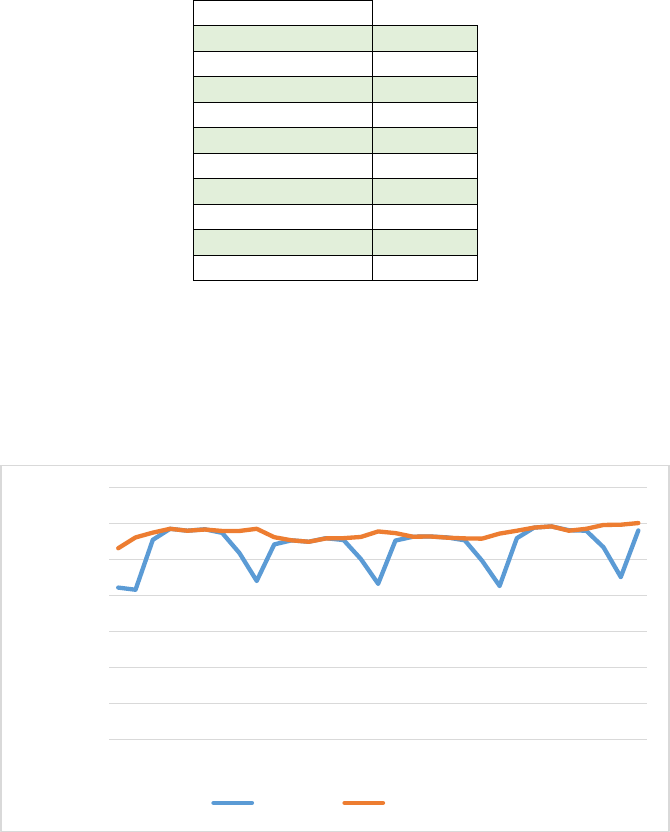

VII. Atmospheric Science Symposium, 28,30 April 2015 İstanbul, www.atmosfer.itu.edu.tr

35

Modelde incelenmesi gereken en önemli gösterge gün tipleri ve zaman trendi için hesaplanan β

katsayılarının(Coefficient*) standart sapmalarına oranını veren t-istatistikleridir. Bu değerlerin hedef değişken

(Tüketim) ile doğru orantıya sahip açıklayıcı değişkenler (gün tipleri ve trend) için 2.16’dan büyük, ters orantılı

açıklayıcı değişkenler için -2.16’dan küçük olması standarttır. Bu standardı sağlayan değişkenler yeterli

anlamlılık seviyesinde görülmektedirler. Görüldüğü gibi kurduğumuz modeldeki tüm değişkenler bu şartı

sağlamaktadır. Ayrıca modelin bütününe yönelik bir açıklayıcılık göstergesi olan R-kare değeri** de %68 gibi

bir oranla sadece gün tipinin bile tüketimi açıklamakta önemli bir yere sahip olduğunu göstermektedir.

Çalışmamızın bir sonraki aşamasında yukardaki model üzerinden elde edilmiş gün tipine özel standart tüketim

değerlerini kullanarak bütün günleri aynı objektif değerlendirebilecek sanal bir zaman serisi oluşturulacaktır.

Basit olarak açıklamak gerekirse 1492 gözlemlik günlük zaman serisindeki tüm günler “ideal gün” olarak seçilen

Çarşamba’ya çevrilecektir.

Gün Tipi İndeksi

1

724,3323

2

101,8093

3

0,029777

4

0

5

-3,63626

6

26,31631

7

307,0205

8

1196,532

9

543,429

10

851,179

Yukarıda verilen tabloda gün tipine karşılık gelen değerler “ideal gün”den farkı vermektedir. Bu durumda bu

farklar yine gün tipine göre tüm gözlemlere eklendiğinde takvim etkisinin ortadan kalkması beklenmektedir.

Aşağıda TÜKETİM* olarak isimlendirilen bu yeni serinin 2011 Ocak ayı tüketim verileri üzerinden hazırlanan

grafiksel karşılaştırması verilmiştir.

Figure 1: Ocak 2011 Tüketim Değerleri

0

500

1000

1500

2000

2500

3000

3500

1 3 5 7 9 11 13 15 17 19 21 23 25 27 29 31

MWh

TÜKETİM TÜKETİM*

[figure not shown]

VII. Atmospheric Science Symposium, 28,30 April 2015 İstanbul, www.atmosfer.itu.edu.tr

36

Grafikte de görüldüğü gibi resmi tatil ve hafta sonları görülen düşüşten tüketim arındırılmış ve istenilen “ideal

gün” serisi oluşturulmuştur. Bundan sonraki aşamada yeni seri ile sıcaklık-tüketim korelasyonunun, HDD ve

CDD değerleri üzerinden yapılan kontrollerle artıp artmadığı kontrol edilecektir.

2.4. HDD, CDD ve Tüketim arasındaki Korelasyonun Belirlenmesi

Çalışmanın birinci amacı sıcaklığın elektrik tüketiminde ne kadar etkili olduğunu ispatlamaktı. Bu doğrultuda,

belirlenen günlük HDD ve CDD değerleri ile elektrik tüketimi arasındaki korelasyonlar belirmiştir. İlk olarak,

aynı tarihlere ait HDD, CDD değerleri ile tüketim verileri arasındaki korelasyonlar direkt olarak hesaplanmıştır.

Fakat elektrik tüketimi takvim etkisinden arındırılmalıdır çünkü tatil, iş günü, bayram, arife, yılbaşı gibi özel gün

tipleri elektrik tüketiminde değişikliklere neden olmaktadır. Tüketim verileri takvim etkisinden arındırıldığında

kalan etkinin sıcaklıktan dolayı olduğu düşünülmektedir. Bunu saptayabilmek için, tüketim verileri gün tiplerine

göre takvim etkisinden arındırılmış ve HDD, CDD ile arasındaki korelasyonlar hesaplanmıştır.

Table 4: HDD, CDD ve tüketim arasındaki korelasyon

Tüketim*: Takvim etkisinden arındırılmış tüketim.

TÜKETİM

TÜKETİM*

HDD14

0,425

0,812

HDD16

0,430

0,819

HDD18

0,431

0,822

CDD20

0,273

0,734

CDD22

0,277

0,735

CDD24

0,283

0,710

kıyaslandığında ikinci korelasyon değerlerinde görülen artışın sıcaklıkla ilgili olduğu söylenebilir. Arındırılmış

tüketim verileri ve sıcaklık değerleri arasındaki ilişki %80 seviyelerine ulaşmıştır. Ayrıca bu tablo İstanbul için

baz kabul edilecek sıcaklık değerini de göstermektedir. HDD, CDD ve arındırılmış tüketim değerleri arasında

2.5. Tahmin Modelinin Kurulması

Korelasyonun takvim etkisinden arındırılmış seri ile daha yüksek değerler verdiğinin sabit olması üzerine tahmin

modelinin kurulması aşamasına geçilmiştir. Burada yine doğrusal regresyon yöntemi kullanılacak ve hedef

değişken olarak da “TÜKETİM*” serisi seçilecektir. Literatürdeki birçok enerji tüketimi tahmin modelinin bir

burada bahsedilmesi gereken önemli bir detaydır. Şöyle ki bu değişkenin modelde bulunması daha önceki

tüketim değerleri ile şimdiki tüketim değerlerinin açıklanabildiği yargısını öne sürmektir. Şebeke tüketiminin

dinamikleri düşünüldüğünde, özellikle de takvim etkisisnden arındırılmış bir seride bir önceki dönemin tüketim

değerleri ile şu anın tüketiminin açıklanması beklenen bir durumdur ve modelde de ilgili değişkenin anlamlılık

seviyesinin(t-istatistiği) yüksek çıkması beklenecektir.

Tüketimle doğru orantılı olduğunu öne sürdüğümüz bu değişkenlerin buna bağlı olarak pozitif katsayılara(β)

[figure not shown]

VII. Atmospheric Science Symposium, 28,30 April 2015 İstanbul, www.atmosfer.itu.edu.tr

37

sahip olmasını ve yine yüksek anlamlılık seviyesi vermesi beklenir bir sonuçtur. Başta da savunduğumuz üzere

bu değerler elektrik tüketimindeki günlük volatilitenin önemli sebeplerinden olacaktır.

Son olarak şebekenin uzun dönemdeki gelişimini göz ardı etmemek amacıyla zaman trendi değişkeni eklenerek

matematiksel model tamamlanacaktır.

3. Sonuçlar

Bölüm 2.5’te planlanan doğrusal regresyon modeli EVIEWS programı üzerinde kurulmuş ve aşağıdaki sonuçlar

alınmıştır.

Table 5: Tahmin Modeli Resgresyon Çıktısı

Dependent Variable: TÜKETİM*

Method: Least Squares

Date: 03/18/15 Time: 10:20

Sample (adjusted): 12/03/2010 12/17/2014

Included observations: 1476 after adjustments

Convergence achieved after 14 iterations

MA Backcast: 12/02/2010

Variable

Coefficient

Std. Error

t-Statistic

Prob.

HDD

26.92590

1.225016

21.98003

0.0000

CDD

38.49177

3.288846

11.70373

0.0000

@TREND

0.216957

0.035359

6.135805

0.0000

@MONTH=1

2651.798

39.42413

67.26332

0.0000

@MONTH=2

2652.753

38.34448

69.18213

0.0000

@MONTH=3

2598.714

37.78736

68.77205

0.0000

@MONTH=4

2549.655

37.28855

68.37636

0.0000

@MONTH=5

2529.773

37.95295

66.65552

0.0000

@MONTH=6

2589.067

39.40918

65.69707

0.0000

@MONTH=7

2587.362

40.73588

63.51556

0.0000

@MONTH=8

2578.504

40.54019

63.60364

0.0000

@MONTH=9

2552.897

40.49861

63.03666

0.0000

@MONTH=10

2568.141

40.67325

63.14079

0.0000

@MONTH=11

2618.730

41.08488

63.73951

0.0000

@MONTH=12

2684.665

41.00229

65.47597

0.0000

AR(1)

1.337639

0.043454

30.78252

0.0000

AR(2)

-0.359595

0.038781

-9.272490

0.0000

MA(1)

-0.841108

0.030669

-27.42531

0.0000

R-squared

0.875114

Mean dependent var

2893.408

Adjusted R-squared

0.873658

S.D. dependent var

216.1810

S.E. of regression

76.84061

Akaike info criterion

11.53346

Sum squared resid

8608731.

Schwarz criterion

11.59806

Log likelihood

-8493.696

Hannan-Quinn criter.

11.55755

Durbin-Watson stat

2.009885

Inverted AR Roots

.97

.37

Inverted MA Roots

.84

Yukarıda verilen tablo incelendiğinde modelin 0.87 ile makul bir açıklayıcılık sunduğu ve kullanılan açıklayıcı

değişkenlerin de yeterli anlamlılık seviyesine sahip olduğu görülmüştür. Aşağıda kullanılan tüm değişkenlerle

ilgili detaylar listelenmiştir.

HDD: Güne ait ısınma derecesinin tüketime etkisi

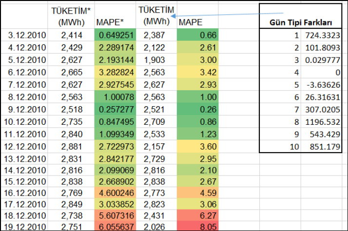

VII. Atmospheric Science Symposium, 28,30 April 2015 İstanbul, www.atmosfer.itu.edu.tr

38

CDD: Güne ait soğuma derecesi tüketime etkisi

@TREND: Uzun dönemde görülebilecek muhtemel şebeke büyümesine bağlı tüketim artışının etkisinin

arındırılması için eklenen değişken

@MONTH: Okul sezonu, piyasalar gibi sezonsal karakteristikleri olan dış etkileri modele dahil etmek için

regresyona eklenmiş, ilgili aya göre “1” yada “0”değerini alan basit değişkenler

AR(1): Bir önceki günün tüketim değerinin bugünün tüketimine etkisi

AR(2): İki önceki günün tüketim değerinin bugünün tüketimine etkisi

MA(1): Tahmin modelinin kendini eğitmesi için geçmiş hata oranının bugünün tahminine etkisini gösteren

değişken. Bu modelde 1. derece yani bir önceki günün tahmin hatası üzerinden hesaplanmıştır.

Bu şekilde hazırlanan modelin tahmin performansına yönelik iki farklı kontrol yöntemi uygulanmıştır. Birinci

yöntemde EVIEWS programı kullanılarak model geçmişe yönelik çalıştırılmış ve tahmin edilen değerler ile

gerçekleşen değerler karşılaştırılmıştır.

Figure 2:Model Performansı Analizi

Hatırlanacağı üzere kullanılan tüketim serisi takvim etkisinden arındırılmıştı(TÜKETİM*). Bir güne ait gerçek

tüketim değerini tahmin etmek için ise takvimsel etkinin tekrar ilave edilmesi gerekmektedir. Yukarıda

görüleceği gibi tahmin modeli geriye doğru çalıştırıldıktan sonra çıkan sonuçlardan “ideal gün” ile olan fark

düşülmüş ve gerçek tüketim değerine yönelik tahmin performansı için bu aşamadan sonraki değerler esas

alınmıştır. Sonuçlar incelendiğinde 4 yıl için %2,9 gibi bir ortalama hata(MAPE) hesaplanmıştır.

İkinci kontrolde ise son iki haftanın(18.12.2014 – 31.12.2014) tüketim değerleri hesaba katılmadan model

kurulmuş ve bu aralık tahmin edilerek gerçek tüketim değeriyle karşılaştırılmıştır.

Table 6: Tahmin Sonuçları

[figure not shown]

VII. Atmospheric Science Symposium, 28,30 April 2015 İstanbul, www.atmosfer.itu.edu.tr

39

(MWh)

(%)

Tarih

Gerçekleşen

Tahmin

MAPE

18.12.2014

3,144

3,145

0.04

19.12.2014

3,129

3,168

1.26

20.12.2014

2,833

2,876

1.50

21.12.2014

2,444

2,469

0.99

22.12.2014

3,165

3,172

0.20

23.12.2014

3,227

3,194

1.01

24.12.2014

3,156

3,159

0.08

25.12.2014

3,111

3,132

0.69

26.12.2014

3,116

3,112

0.12

27.12.2014

2,923

2,946

0.81

28.12.2014

2,493

2,564

2.83

29.12.2014

3,154

3,133

0.66

30.12.2014

3,425

3,425

0.00

31.12.2014

3,215

3,369

4.81

Bu performans kontrolünde de makul bir başarı oranı sağlandığı görülmüştür. Matematiksel açıklamalarla da

kanıtlandığı üzere çalışmamızda öne sürdüğümüz iki argüman olan, takvimsel etkiden arındırıldığında tüketimin

sıcaklıkla olan korelasyonunun artacağı ve HDD ve CDD üzerinden kurulan tahmin modelinin tüketimdeki

günlük volatiliteyi iyi açıklayabilmesi, elektrik tüketimini etkileyen önemli dinamiklere ışık tutmaktadır.

Sonuç olarak elektrik tüketimi tahminine yönelik tahminlerde modelleme kadar, kullanılan değişkenlerin

analizinin de çok önemli bir aşama olduğu görülmüştür. Örneğin HDD ve CDD ısınmaya veya soğumaya

harcanan enerjiyi sıcaklıktan daha iyi yansıtabilecek birer değişken olarak tahmin modeline önemli oranda

pratiklik kazandırmaktadır. Ayrıca takvimsel etkiden arındırıldığında bu pozitif korelasyon daha objektif

sonuçlar sunmaktadır.

Elektrik tüketimi tahmininde, doğrusal regresyon dışında, yapay sinir ağları, fourrier serileri, üstel doğrulama

gibi lineer özellik taşımayan tahmin modelleri de kullanılmaktadır. Bu bakımdan çalışmamızda kullandığımız

model daha basit bir açıklama yöntemi olarak temel dinamikleri açıklamaya yönelik planlanmıştır. Hava

sıcaklığı-tüketim ilişkisini başarılı bir şekilde yansıtan bu çalışma faklı tahmin modelleriyle geliştirilebilir olması

dolayısıyla pilot bir proje olma özelliği de taşımaktadır.

Kaynaklar

Güneği, O., O., “Elektrik Enerjisinde Yeni Dönem”, DPT Planlama Dergisi, Özel Sayı, Ankara, Türkiye, 2002.

Özkan, D., Kakilli, A., ve Tektaş, M., “Anfıs ve Arma Modelleri İle Elektrik Enerjisi Yük Tahmini”, Gazi Üniv.

Müh. Mim. Fak. Der., 601-610, 2010. )

Vardoulakis, E., Karamanis, D., Fotiadi, A., Mihalakakou, G., “The urban heat island effect in a small

Mediterranean city of high summer temperatures and cooling energy demands”, Department of

Environmental & Natural Resources Management, University of Ioannina, 2013.

Yüksel, Ü., D., ve Yılmaz, O.,“Ankara Kentinde Kentsel Isı Adası Etkisinin Yaz Aylarında Uzaktan Algılama ve

Meteorolojik Gözlemlere Dayalı Olarak Saptanması ve Değerlendirilmesi”, 2008.